# OLS: Asymptotics

We’ve discussed the OLS Assumptions up until this point:

1. $y=\beta_0 + \beta_1x_1+\beta_2x_2 + \dots + \beta_kx_k + u$ (linearity)
2. Random sampling from the population

${(u_i,X_i), i =1, \dots, N}$ is a random sample from the $(u, X)$ population where $(u_i, X_i)$ are i.i.d. (independently and identically distributed)

3. no perfect collinearity in the sample (aka non redundancy)

$\sum^n_{i=1} (X_i-\bar{X})^2>0$

4. $E(u|x_1,\dots,x_k) = E(u) = 0$ (zero conditional mean)
5. $Var(u|x_1, \dots, x_k) = Var(u) = \sigma^2$ (homoskedasticity)
6. $u_i | X_i \overset{\text{iid}}{\sim} \mathcal{N}(0,\sigma^2_u)$ The distribution u given $(x_1, \dots, x_k$ is $Normal(0,\sigma^2)$ (Normality of the error term)

Assumptions 1 - 4 ensure unbiasedness in our parameter estimation aka $E(\hat{\beta_j})=\beta_j$

Assumptions 1-5 are the Gauss-Markov assumptions aka BLUE

Assumption 1-6 are the classic linear assumptions and do exact statistical inference.

Sometimes, you’ll see the conditional expectation function written as:

$E(Y_i|X_i) = \beta_0 + \beta_1X_i$

This implies:

1. The conditional expectation of $Y_i$ is linear in $X_i$ (Asmp. 1)
2. the error term is mean-independent of the regressor (Asmp. 4)
3. the error term is distribution around zero. (Asmp. 5)

Assumptions 1, 5 and 6 are easier to relax. Assumption 2 is easy to implement and assumption 3 is data dependent, but will be important for panel data. Assumption 4 - which we’ve discussed a lot, is what a lot of econometrics is all about.

We can write assumptions 1,3,4,5 concisely:

$Y_i | X_i \overset{\text{iid}}{\sim} \mathcal{N}(\beta_0 +\beta_1X_i, \sigma^2)$

or

$u_i | X_i \overset{\text{iid}}{\sim} \mathcal{N}(0, \sigma^2_u)$

Last class we talked about inference and issues with inference when dealing with the standard errors of our parameters.

### Heteroskedasticity

I’d like to quickly review what happens when we break assumption 5 (homoskedasticity which means equal spread) and what it means.

We’ll go over this in more detail in 2 weeks - but, here is a quick moment on it.

Last class we went into detail about how our standard errors are calculated and issues with multicollinearity - ths isn’t a violation of any of the assumptions that we’ve outline.

For a brief moment, let me remind you about Heteroskedasticity. This occurs when Assumption 5 is violated - when the variances differ.

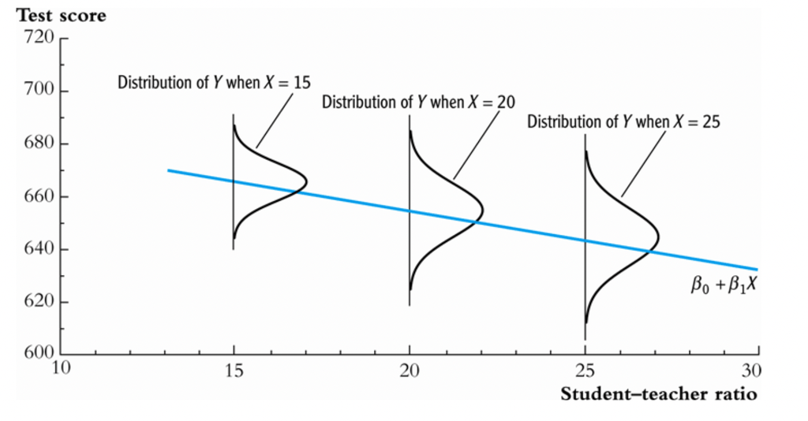

Example of heteroskedasticity

What does heteroskedasticity mean?

1. Estimates for $\beta_0, \beta_1, \dots, \beta_k$ are still unbiased.
2. Estimates for $\beta_0, \beta_1, \dots, \beta_k$ are no longer efficient. You can get better estimates (with smaller MSE).
3. Inference is in trouble. Given heteroskedasticity, the homoskedasticity only standard errors are wrong, so the t-stats/p-values are wrong and the CI’s are wrong too.

What to do? How do I find heteroskedasticity?

- Graphical tools, examine the scatter plot check if variance is increasing or decreasing. Often it’s very obvious (think age-earnings regressions).
- Don’t care. Always make inference robust.
- Test formally (Breusch-Pagan test or White test) and then use FGLS.

In simple OLS, $E[Y|X] = \beta_0 + \beta_1 X$, the homoskedasticity only variance is

$$\begin{equation}
\text{Var}(\hat{\beta}_1) = \frac{\sigma_u^2}{\sum_i (X_i-\bar{X})^2}
\end{equation}$$

Recall, that the sampling variance of our estimator depends on: - the error variance (of which it is directly proportional) - the sample size N - the regressor variance of which it is inversely proportional

You’ve seen this written as:
$$\begin{equation}
\text{Var}(\hat{\beta}_1) = \frac{\sigma^2}{SST_j(1-R^2_j)}
\end{equation}$$

The asymptotic variance under **heteroskedasticity** is

$$\begin{equation}
\text{Var}(\hat{\beta}_1) = \frac{\sum_i \sigma_u^2 \omega_i (X_i-\bar{X})^2}{[\sum_i (X_i-\bar{X})^2]^2}
\end{equation}$$

The White heteroskedasticity consistent (HC) estimator is

$$\begin{equation}
\widehat{\text{Var}}(\hat{\beta}_1) = \frac{\sum_i \hat{u}_i^2 (X_i-\bar{X})^2}{[\sum_i (X_i-\bar{X})^2]^2}
\end{equation}$$

The usual t-tests and F-tests using the HC covariance estimator are only asymptotically valid.

Let’s see an example.

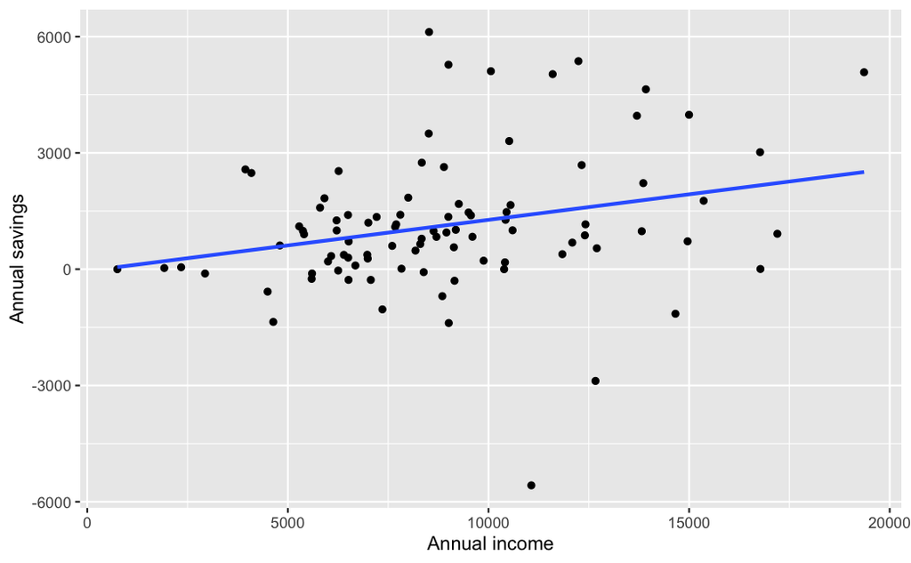

```r
library(wooldridge)
library(dplyr)
library(ggplot2)

# pulling wooldridge data
data('saving')

# Only use positive values of saving, which are smaller than income
saving <- saving %>% filter(
         inc < 20000,
         sav < inc)

ggplot(saving, aes(x = inc, y = sav)) +
  geom_point() +
  geom_smooth(method = "lm", se = FALSE) +
  labs(x = "Annual income", y = "Annual savings")
```

Let’s estimate a simple model:

```r
savingsmodel <- lm(sav ~ inc, data = saving)

summary(savingsmodel)
```

```
Call:
lm(formula = sav ~ inc, data = saving)

Residuals:
    Min      1Q  Median      3Q     Max
-6990.9  -813.2  -187.1   486.0  5042.0

Coefficients:
             Estimate Std. Error t value Pr(>|t|)
(Intercept) -45.31189  483.10505  -0.094   0.9255
inc           0.13184    0.05037   2.617   0.0104 *
---
Signif. codes:  0 ‘***’ 0.001 ‘**’ 0.01 ‘*’ 0.05 ‘.’ 0.1 ‘ ’ 1

Residual standard error: 1715 on 91 degrees of freedom
Multiple R-squared:   0.07, Adjusted R-squared:  0.05979
F-statistic:  6.85 on 1 and 91 DF,  p-value: 0.01038
```

Now, let’s compare to robust standard errors

```r
library("lmtest")
library("sandwich")

# Robust t test
coeftest(savingsmodel, vcov = vcovHC(savingsmodel, type = "HC0"))
```

[output not shown]

### A note about Adjusted R-squared

The Sum of Squares decomposition still holds with $K$ regressors

$$\sum_{i=1}^N (Y_i - \bar{Y})^2 = \sum_{i=1}^N (\hat{Y}_i - \bar{Y})^2 + \sum_{i=1}^N \hat{u}_i^2$$

However, the $R^2$ keeps going up when we add (even meaningless) regressors. So we introduce a penalty

This is the Adjusted $R^2$
$$\bar{R}^2 \equiv 1 - \left(\frac{N-1}{N-K-1}\right) \frac{\sum_{i=1}^N \hat{u}_i^2}{\sum_{i=1}^N (Y_i - \bar{Y})^2}$$

Similarly, the $SER$ now needs to be adjusted for the extra degrees-of-freedom used during the estimation

$$SER \equiv s_{\hat{u}} = \sqrt{\frac{1}{N-K-1}\sum_{i=1}^N \hat{u}_i^2}$$
Can the adjusted $R^2$ ever be negative?

What happens if we include an irrelavant variable? Let’s see an example…

```r
mlb <-lm(lsalary ~years + gamesyr+bavg + hrunsyr+rbisyr, data = mlb1)

mlb2 <-lm(lsalary ~years + gamesyr+bavg + hrunsyr+rbisyr+percwhte, data = mlb1)
summary(mlb)
```

```
Call:
lm(formula = lsalary ~ years + gamesyr + bavg + hrunsyr + rbisyr,
    data = mlb1)

Residuals:
     Min       1Q   Median       3Q      Max
-3.02508 -0.45034 -0.04013  0.47014  2.68924

Coefficients:
             Estimate Std. Error t value Pr(>|t|)
(Intercept) 1.119e+01  2.888e-01  38.752  < 2e-16 ***
years       6.886e-02  1.211e-02   5.684 2.79e-08 ***
gamesyr     1.255e-02  2.647e-03   4.742 3.09e-06 ***
bavg        9.786e-04  1.104e-03   0.887    0.376
hrunsyr     1.443e-02  1.606e-02   0.899    0.369
rbisyr      1.077e-02  7.175e-03   1.500    0.134
---
Signif. codes:  0 ‘***’ 0.001 ‘**’ 0.01 ‘*’ 0.05 ‘.’ 0.1 ‘ ’ 1

Residual standard error: 0.7266 on 347 degrees of freedom
Multiple R-squared:  0.6278,    Adjusted R-squared:  0.6224
F-statistic: 117.1 on 5 and 347 DF,  p-value: < 2.2e-16
```

```r
summary(mlb2)
```

```
Call:
lm(formula = lsalary ~ years + gamesyr + bavg + hrunsyr + rbisyr +
    percwhte, data = mlb1)

Residuals:
     Min       1Q   Median       3Q      Max
-2.94530 -0.45128 -0.05529  0.47771  2.61183

Coefficients:
             Estimate Std. Error t value Pr(>|t|)
(Intercept) 11.546103   0.384344  30.041  < 2e-16 ***
years        0.074821   0.012665   5.908  8.8e-09 ***
gamesyr      0.010857   0.002762   3.930 0.000104 ***
bavg         0.001696   0.001423   1.192 0.234043
hrunsyr      0.007024   0.016572   0.424 0.671979
rbisyr       0.013407   0.007424   1.806 0.071876 .
percwhte    -0.006414   0.002670  -2.402 0.016864 *
---
Signif. codes:  0 ‘***’ 0.001 ‘**’ 0.01 ‘*’ 0.05 ‘.’ 0.1 ‘ ’ 1

Residual standard error: 0.7265 on 323 degrees of freedom
  (23 observations deleted due to missingness)
Multiple R-squared:  0.6169,    Adjusted R-squared:  0.6098
F-statistic: 86.69 on 6 and 323 DF,  p-value: < 2.2e-16
```

### MLE Estimation

I made you read a part of Hayashi’s book on MLE and I’d like to return to it for a moment.

The PDF (probability distribution function) of $Y_i$ given $X_i$ is known *except* for only three parameters, $\beta_0, \beta_1, \sigma^2_u$:

$$\begin{equation}
f_{Y_i|X_i}(y) = \frac{1}{\sqrt{2\pi\sigma^2_u}}exp(-\frac{1}{2\sigma^2_u}(Y_i - \beta_0 + \beta_1X_i)^2)
\end{equation}$$

With the assumption of normality, we can use maximum liklihood estimation.

The basic idea is that we choose parameter estimates to maximize a measure of the likeliness of the sample outcomes - this is called the liklihood function. ML estimators of $\beta_0$ and $\beta_1$ are those values that $\hat{\beta_0}$ and $\hat{\beta_1}$ can best describe the full distribution of the data.

The liklihood function is the joint probability function of $Y_1$ conditional on $X_1$.

Now, it’s *way* easier to deal with the log of some function - which we call a logliklihood function, where all we do is replace the hypothetical values and take the logs. Think about that exp function in the pdg. If we take the log of an exponential - that makes the form easier to deal with (recall $y = b^x = log_b(y) = x$)

Fortunately, ML estimators is equivalent to maximizing the loglikelihood function.

You essentially set the derivatives of the logliklihood function equal to zero and solve for first-order conditions. This doesn’t provide a closed form formulate, and usually we use numerical methods that guess a number, solve for it and then take the second derivative to see if the slope is positive or negative and once it’s close to zero, you’ve found a solution. Hence, MLE has successive iterations.

What is nice about using MLE is that the variance is unbiased! When we use OLS - the variance is not unbiased. No where did we make that a requirement with our as sumption (indeed, $\beta_1$ is unbiased). So, MLE is incredibly *efficient* and our issue with multi-collinearity dissappears.

The properties of MLE are asymptotic - they are approximate in real-world samples - and as N gets larger, we know it will approximate to the true value.

This is a different *estimation* method. The model can be the same for OLS and MLE, but the estimation method is different. OLS minimized the sum of squares. MLE maximizes the liklihood funciton.

As a result, there is not $R^2$ in MLE. Instead, we use log-liklihood ratios - and that is basically an F-test!

So, here we are full-circle. The logliklihood ratio is:

$(\frac{SSR_u}{SSR_R})^{-n/2}$

where we compare our restricted model to our unrestricted model.

So, you may ask, why the heck are we talking about this? Well, for one estimation method is different from model. But, also, MLE is exactly what we do in the case if probit and logit models where the dependent variable is binary. If we have time, we’ll come back to this.

In addition, this points out how estimation models that may have the same assumptions can have different properties - particularly, MLE is efficient because we can accurately estimate the variance of our estimator.

Why don’t we just use this all the time? Because the assumption of normality is too strict and we rarely it in the data wild.

### Large Sample Asymptotics

We’ve reviewed assumptions that ensures OLS is BlUE under finite-sample theory - when you use a sample of a given size. The Gauss-Markov assumptions hold for a dataset of *any* size.

We’re going to talk about what happens with large-samples - we will make assumptions about the stochastic process that generates the sample.

What we’re asking is - how do estimators and test statistics change as the sample size grows to infinity?

#### Consistency

As we get more data, we can expect the sampling distribution of $\hat{\beta_j}$ to become more tightly centered around $\beta_j$

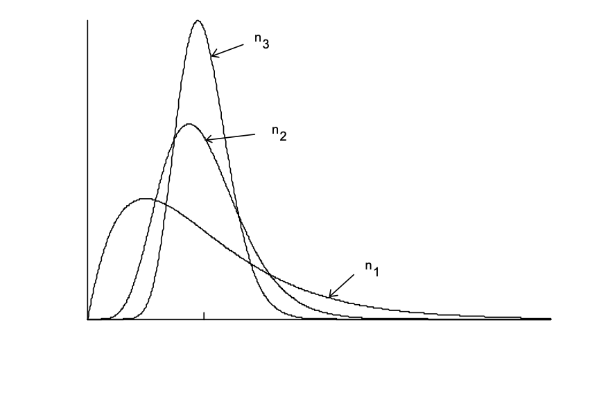

Sampling distributiongs pf $\hat{\beta_j}$

To prove consistency, we need to use the LLN - which holds under random sampling. In Simple OLS:

$$\begin{equation}
\hat{\beta_1} = \beta_1 + \frac{n^{-1}\sum^n_{i=1}(x_i-\bar{x_i})u_i}{n^{-1}\sum^n_{i=1}(x_i-\bar{x_i})^2}
\end{equation}$$

$$\begin{equation}
plim(\hat{\beta_1}) = \beta_1 + \frac{Cov(x_1,u)}{Var(x_1)}
\end{equation}$$

Because of Assumption 4, $E(u|x_1) = 0$ and that for Assumption 3 $(Var(x_1))>0$:

$$\begin{equation}
plim(\hat{\beta_1}) = \beta_1 + \frac{0}{Var(x_1)}
\end{equation}$$

Which is just equal to $\beta_1$

Previously we used Assumption 4 to show unbiasedness, but with consistency, we can think about how the zero correlation is also justified.

What happens is $x_i$ and $u$ are correlated?

$$\begin{equation}
plim(\hat{\beta_1}) = \beta_1 + \frac{Cov(x_1,u)}{Var(x_1)}
\end{equation}$$

$plim(\hat{\beta_1}) >\beta_1$ if $Cov(x_1,u)>0$ $plim(\hat{\beta_1}) <\beta_1$ if $Cov(x_1,u)<0$

Similar to OVB, we can that inconsistency of OLS has similar effects as OVB and relies on the correlation between the the variable X and the error term and the sign of the estimator

|  | $Corr(x_1,x_2)>0$ | $Corr(x_1,x_2)<0$ |
| --- | --- | --- |
| $\beta_2 >0$ | $plim(\tilde{\beta_1})>\beta_1$ | $plim(\tilde{\beta_1})< \beta_1$ |
| $\beta_2 <0$ | $plim(\tilde{\beta_1})<\beta_1$ | $plim(\tilde{\beta_1})> \beta_1$ |

But, if $x_1$ and $x_2$ are uncorrelated then$\tilde{\beta_1}$ is consistent for $\beta_1$, even if $\beta_2 \neq 0$.

#### Asymptotic Normality and Large Sample Inference

Consistency is important, but it’s not enough for statistical inference.

Our CLM assumptions (and in particular, normality) allow use to derive exact t and F distributions for our t and f statistics.

Let’s take an example from the apple dataset - the variable ecolbs is clearly not normal.

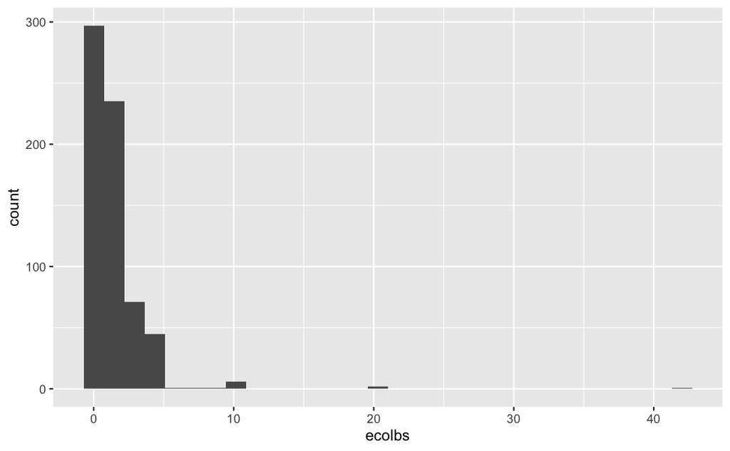

```r
data('apple')

ggplot(apple, aes(x=ecolbs)) +   geom_histogram()
```

```r
NA
NA
```

Or let’s take the example in the 401k data of the percentage of employees at a firm participates in in a 401k pension plan

```r
data('401kpart')
```

```
data set ‘401kpart’ not found
```

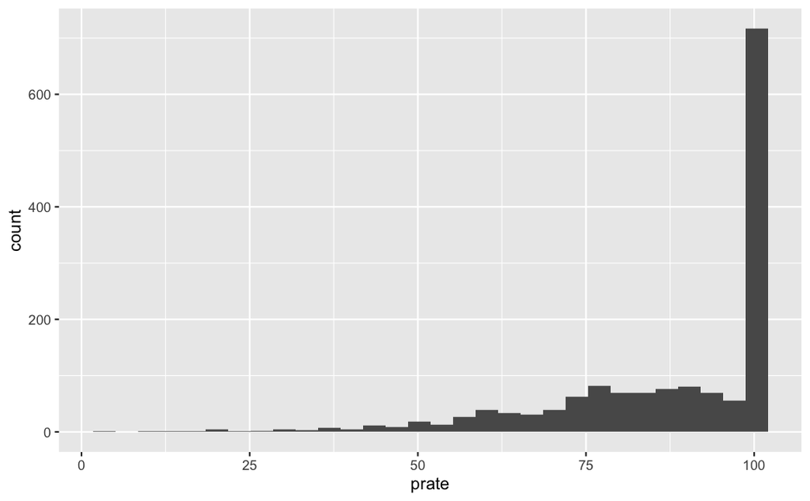

```r
ggplot(k401k, aes(x=prate)) + geom_histogram()
```

We don’t abandon statistical inference - at least if our sample size is reasonably large.

With asymptotic normality of OLS, the standardized version of $\hat{\beta_j}$ is asymptotically standard normal:

$$\begin{equation}
\frac{\hat{\beta_j}-\beta_j}{sd(\hat{\beta_j})} \overset{\text{a}}{\sim} Normal(0,1)
\end{equation}$$

and this convergence holds when we replace $sd(\hat{\beta_j})$ with $se(\hat{\beta_j})$

This means that we can “relax” the assumption of normality with tcaveate that testing is *approximate* with large samples.

We never know how large n has to be for approximation to work - it depends how far the population distribution is from normal - but, generally, above a few hundred makes the approximation good. This is often just assumed by applied researchers.

Note: that when we use CLT, it does not impact our error term. The distribution of u is either normal or not.

What CLT does is it worked on the standardized sample averages from almost any population.

```r
data('econmath')

summary(lm(log(score) ~ colgpa +actmth +acteng, data=econmath))
```

```
Call:
lm(formula = log(score) ~ colgpa + actmth + acteng, data = econmath)

Residuals:
     Min       1Q   Median       3Q      Max
-1.04784 -0.07793  0.01189  0.10046  0.45599

Coefficients:
            Estimate Std. Error t value Pr(>|t|)
(Intercept) 3.402592   0.045096  75.453  < 2e-16 ***
colgpa      0.184799   0.011515  16.049  < 2e-16 ***
actmth      0.013015   0.001807   7.204 1.34e-12 ***
acteng      0.001823   0.001788   1.019    0.308
---
Signif. codes:  0 ‘***’ 0.001 ‘**’ 0.01 ‘*’ 0.05 ‘.’ 0.1 ‘ ’ 1

Residual standard error: 0.1666 on 810 degrees of freedom
  (42 observations deleted due to missingness)
Multiple R-squared:  0.367, Adjusted R-squared:  0.3647
F-statistic: 156.5 on 3 and 810 DF,  p-value: < 2.2e-16
```

[output not shown]